# Do short term rates lead long term rates?

Testing a Vector Error Correction Model

Author

Sean Cannon

Published

March 30, 2024

```r
rm(list=ls())
graphics.off()
knitr::opts_chunk$set()

require(fpp3)
require(tsibble)
require(tidyverse)
require(tidyquant)
require(kableExtra)
require(timetk)
require(vars)
require(lmtest)
require(reshape2)
require(urca)
require(stargazer)
require(tsDyn)
```

## Introduction

Interest rates are a key macroeconomic variable and are closely watched by investors and economists. Treasury debt instruments are generally seen as free of default risk and are frequently used as a comparison for valuing other investments. In addition, the treasury yield curve is used as an overall indicator of economic outlook. This analysis will seek to answer the following questions:

- What is the dynamic relationship between the 2 and 10 year treasury debt yields?
- Do short short term rates lead long term rates?

This analysis uses a time-series tools from Forecasting: Principles and Practice written by Rob J Hyndman and George Athanasopoulos.<sup>[1]</sup>

## Data

```r
# Vector of variables to be gathered:
vars <- c("GS2","GS10")

# Use tidyquant function tq_get to gather economic data from FRED and format as a tsibble
fred_data <- tq_get(vars,
                    get = "economic.data",
                    from = "1977-01-01",
                    to = "2022-03-01")

# Pivot the data to be in a more conventional wide format
fred_dataw <- fred_data %>%
  pivot_wider(names_from = symbol, values_from = price) %>%
  tidyr::drop_na() %>%
  as_tsibble(index = date) %>%
  mutate(gs2 = `GS2`, gs10 = `GS10`) %>%
  dplyr::select(-c(`GS2`, `GS10`))
```

The data used in this analysis was gathered from the Federal Reserve’s online database (FRED). The time series spans from January 1977 to March 2022.

Refer to the table below for a list of the variables used and their attributes.

Source: Federal Reserve Economic Data (FRED)

| Variables | Description | Units |
| --- | --- | --- |
| GS2 | Market Yield on U.S. Treasury Securities at 2-Year Constant Maturity | Percent, Not Seasonally Adjusted |
| GS10 | Market Yield on U.S. Treasury Securities at 10-Year Constant Maturity | Percent, Not Seasonally Adjusted |

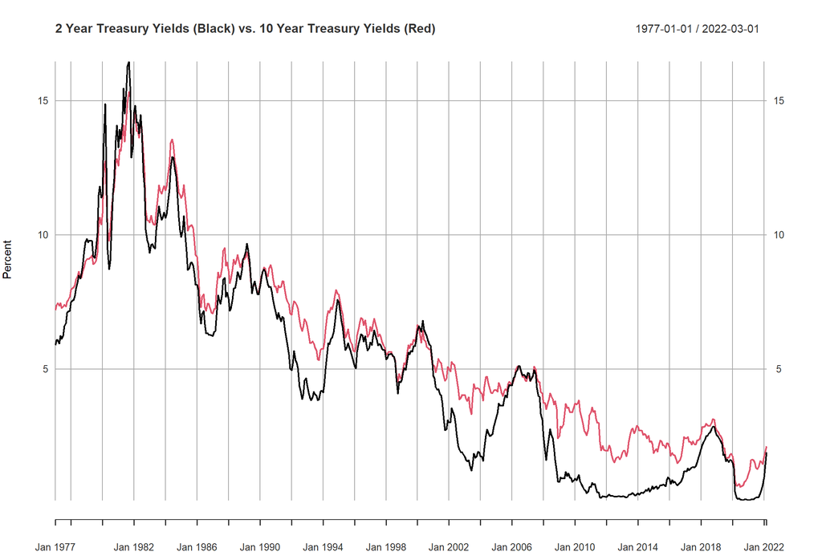

```r
# plot
spread <- xts::xts(fred_dataw[,-1], order.by = fred_dataw$date)
plot(spread, main = "2 Year Treasury Yields (Black) vs. 10 Year Treasury Yields (Red)", ylab = "Percent", xlab="Month")
```

Above is a chart of the yields on 2 and 10 year treasury notes from 1977 to the present. The two rates are highly correlated, and follow the same general shifts over time. Periods when the ten year note yield crosses over the two year yield are an inversion of the yield curve, when rates for short term debt are higher than long term. Since yield curve inversions go against basic time value of money principles, this is generally seen as an indicator of an economic downturn. Understanding the dynamics between the two rates can be useful in predicting the future spread between debt of varying yield to maturity.

`GS2` and `GS10` are monthly measures of the yield on 2 and 10 year treasury securities, respectively. They track the interest rate over time; the difference between them is the spread between the 2 year and 10 year treasury notes. The variables are both influenced by the same macroeconomic factors. Therefore, they exhibit a high degree of correlation.

## Model Selection

```r
# test for unit roots
# summary(ur.df(spread$gs2, type = "none", selectlags = "BIC"))
# summary(ur.df(spread$gs10, type = "none", selectlags = "BIC"))

# test for cointegration

# coint.tr <- lm(spread$gs2 ~ spread$gs10)
# summary(coint.tr)

# examine residuals for cointegration: residuals I(0)
# coint.tr.resids <- coint.tr$residuals
# summary(ur.df(coint.tr.resids, type = "drift", selectlags = "BIC"))
```

Prior to selecting a model, it’s important to test the order of integration of each time series. If `GS2` or `GS10` contain a unit root, they are non-stationary processes. If the variables contain a random walk component, they usually require differencing to be made stationary before performing any time series analysis. An Augmented Dickey-Fuller test can be used to test whether `GS2` or `GS10` contain a unit root.

$$\text{Augmented Dickey-Fuller Test}$$

$$H_0:\text{There is a unit root}$$

$$H_a:\text{There is no unit root}$$

$$\text{Estimate: }y_t=\alpha+\beta x_{t}+\epsilon_{t}$$

$$\text{Test if: }\hat{\varepsilon}_t\sim \text{I(0)}$$

```r
# estimate a VECM model with p-1 lags
p.tr <- vars::VARselect(spread[,c(2,1)],lag.max=20,type="const")$selection[2] - 1
spread.vecm <- tsDyn::VECM(spread[,c(2,1)],lag=p.tr,r=1,include="const",estim="ML",LRinclude="none")
```

We will follow the lag selection rule $p -1$ where $p$ is the number of lags (one lag is lost through differencing). Our model will include 6 lags, the optimal number as calculated by the algorithm. Since a six lag model would be very long to write, consider a more simple example with two variables and two lags:

$$\text{Vector Error Correcton Model}$$

$$t_{1,t}=c_{1}+\phi_{11,1}y_{1,t-1}+\phi_{12,1}y_{2,t-1}+\epsilon_{1,t}$$

$$t_{2,t}=c_{2}+\phi_{21,1}y_{1,t-1}+\phi_{22,1}y_{2,t-1}+\epsilon_{2,t}$$

## Results

The impulse response function illustrates the dynamic relationship between two variables estimated by VEC. First, the model is run out to steady state, then one of the variables is given a random shock. The top impulse response function shows the result of issuing a random shock to the `GS10` variable. `GS2`, the two year note yield, is quick to adjust to the elevated rate of the 10 year treasury note. Economically, this would result in a narrowing of the spread between the two notes in the short term.

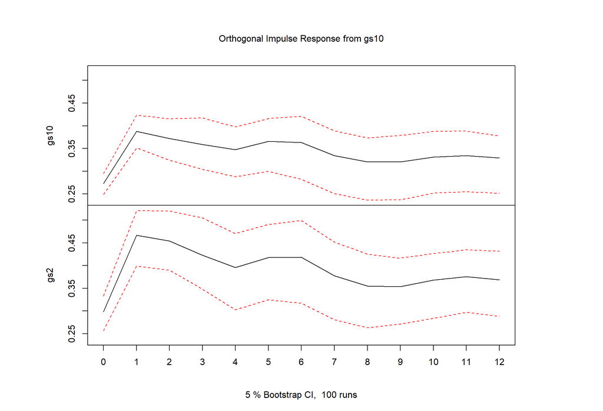

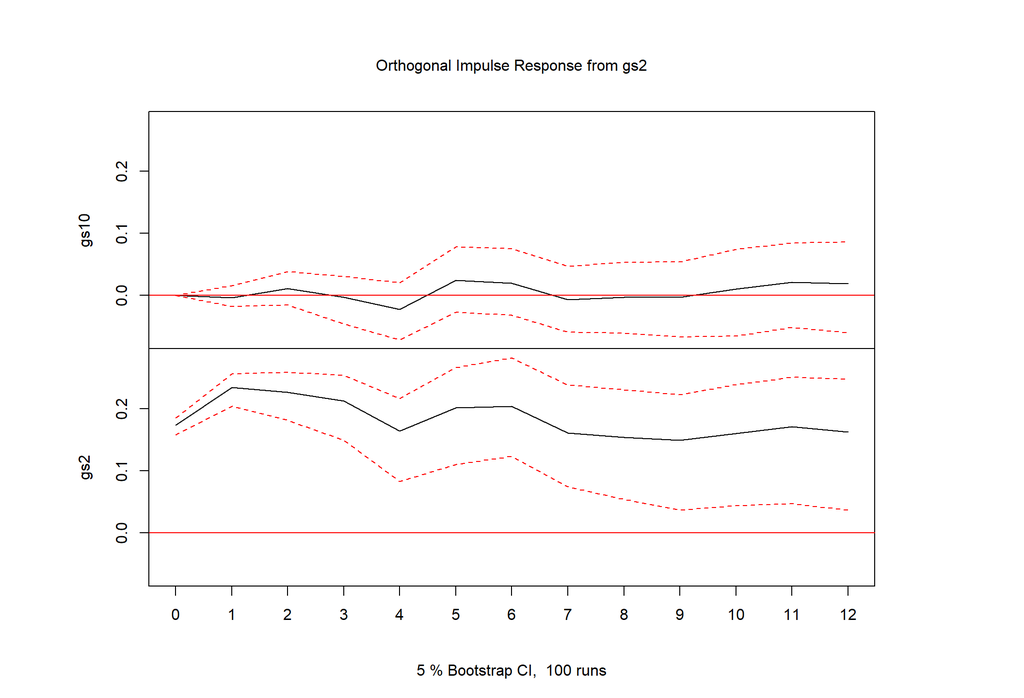

```r
plot(irf(spread.vecm, n.ahead = 12))
```

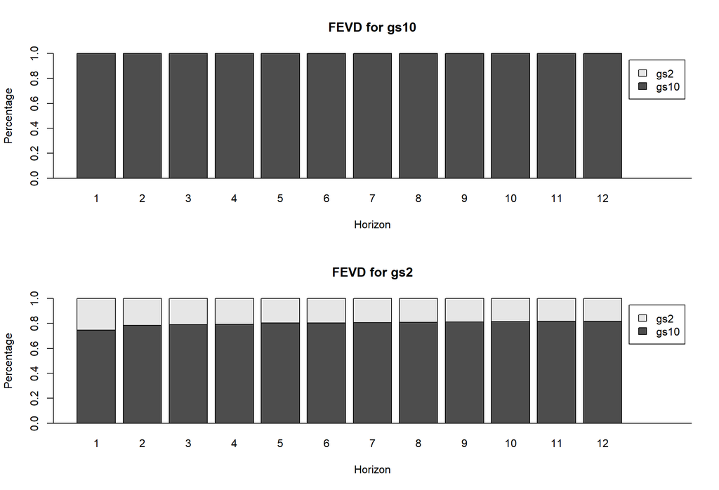

```r
plot(fevd(spread.vecm, n.ahead = 12))
```

## Summary

Overall, this analysis indicates that the two year treasury note yield reacts to shocks in the ten year treasury yield. More analysis is required to determine whether or not short term rates lead long term rates. These findings imply that when long term rates change, short term rates will react to close the spread. However, the reverse does not appear to be true.

## References

<sup>[1]</sup> Hyndman, Rob J. “Forecasting: Principles and Practice (3rd Ed).” OTexts. Accessed April 10, 2022. https://otexts.com/fpp3/.